# Interact with Twitter’s APIs using rtweet

Jiaying Wu

```r
# load twitter library - the rtweet library is recommended now over twitteR
library(rtweet)
# tidyverse!
library(tidyverse)
# text mining library
library(tidytext)
```

### Twitter developer account

1. Apply a development account from the twitter developer: https://developer.twitter.com/en/portal/petition/use-case
2. After you created the developer account, `Create Project` from the Twitter Developer Portal Dashboard: https://developer.twitter.com/en/portal/dashboard
3. Go to the `Settings` tab, change the `App perissions` to `Read and write`.

### rtweet

The first thing that you need to setup in your code is your authentication. These keys are located in the `Keys and tokens` tap of your project.

`API Key and Secret` of `Consumer Keys` section:

- `app`: App name
- `consumer_key`: API Key
- `consumer_secret`: API Key Secret

`Access Token and Secret` of `Authentication Tokens` section:

- `access_token`: Access Token
- `access_secret`：Access Token Secret

You will need to copy the information your keys and tokens to replace the `Your-App-Name`, `Your-API-Key`, `Your-API-Secret-Key`, `You-Access-Token` and `You-Access-Token-Secret`

```r
# App name (example below is not a real app name)
app_name <- "Your-App-Name"

## API Key (example below is not a real key)
api_key <- "Your-API-Key"

# API Key Secret (example below is not a real key)
api_secret <- "Your-API-Key-Secret"

# Access Token (example below is not a real token)
access_token <-  "You-Access-Token"

# Access Token Secret (example below is not a real token)
access_secret <- "You-Access-Token-Secret"
```

```r
# create token named "twitter_token"
twitter_token <- create_token(
  app = app_name,
  consumer_key = api_key,
  consumer_secret = api_secret,
  access_token = access_token,
  access_secret = access_secret)
```

Finally, you can create a token that authenticates access to tweets, let start exploring the Twitter data!

### Search for Tweets

The `search_tweets()` will get tweets data on statuses identified via search query. But it will only return data from the past 6-9 days.

- q: the query word that you want to look for
- n: the number of tweets that you want returned. You can request up to a maximum of 18,000 tweets.

To see what other arguments you can use with this function, use the R help:

```
?search_tweets
```

```r
## search for 500 tweets using the #rstats hashtag
rstats_tweets <- search_tweets(q = "#rstats", n = 50)
# view the first 3 rows of the dataframe
head(rstats_tweets, n = 5)
```

```
## # A tibble: 5 × 90
##   user_id             status_id  created_at          screen_name text     source
##   <chr>               <chr>      <dttm>              <chr>       <chr>    <chr>
## 1 951690486917582850  145594645… 2021-11-03 17:14:19 IoTtogether "Deep r… Retwe…
## 2 1336432915941474305 145594644… 2021-11-03 17:14:17 DjangoBot_  "https:… djang…
## 3 1336432915941474305 145594365… 2021-11-03 17:03:11 DjangoBot_  "Deep L… djang…
## 4 1053697748321501184 145594634… 2021-11-03 17:13:53 PinakiLask… "Deep r… Twitt…
## 5 1053697748321501184 145594631… 2021-11-03 17:13:47 PinakiLask… "Deep r… Twitt…
## # … with 84 more variables: display_text_width <dbl>, reply_to_status_id <lgl>,
## #   reply_to_user_id <lgl>, reply_to_screen_name <lgl>, is_quote <lgl>,
## #   is_retweet <lgl>, favorite_count <int>, retweet_count <int>,
## #   quote_count <int>, reply_count <int>, hashtags <list>, symbols <list>,
## #   urls_url <list>, urls_t.co <list>, urls_expanded_url <list>,
## #   media_url <list>, media_t.co <list>, media_expanded_url <list>,
## #   media_type <list>, ext_media_url <list>, ext_media_t.co <list>, …
```

### Retweets

A retweet is when you or someone else shares someone else tweet so your / their followers can see it. It is similar to sharing in Facebook where you can add a quote or text above the retweet if you want or just share the post. Let’s use the same query that you used above but this time ignore all retweets by setting the `include_rts` argument to `FALSE`. You can get tweet / retweet stats from your dataframe, separately.

```r
# find recent tweets with #rstats but ignore retweets
rstats_tweets <- search_tweets("#rstats", n = 500, include_rts = FALSE)
# The frist 6 rows
head(rstats_tweets)
```

```
## # A tibble: 6 × 90
##   user_id             status_id  created_at          screen_name  text    source
##   <chr>               <chr>      <dttm>              <chr>        <chr>   <chr>
## 1 1053697748321501184 145594631… 2021-11-03 17:13:47 PinakiLaskar "Deep … Twitt…
## 2 1053697748321501184 145575715… 2021-11-03 04:42:05 PinakiLaskar "How t… Twitt…
## 3 1053697748321501184 145594177… 2021-11-03 16:55:44 PinakiLaskar "Vecto… Twitt…
## 4 1053697748321501184 145594136… 2021-11-03 16:54:05 PinakiLaskar "Bound… Twitt…
## 5 1420994827          145594522… 2021-11-03 17:09:26 TheStephLoc… "Do I … Twitt…
## 6 1264433760          145594455… 2021-11-03 17:06:46 Eli_Krumova  "Creat… Twitt…
## # … with 84 more variables: display_text_width <dbl>, reply_to_status_id <chr>,
## #   reply_to_user_id <chr>, reply_to_screen_name <chr>, is_quote <lgl>,
## #   is_retweet <lgl>, favorite_count <int>, retweet_count <int>,
## #   quote_count <int>, reply_count <int>, hashtags <list>, symbols <list>,
## #   urls_url <list>, urls_t.co <list>, urls_expanded_url <list>,
## #   media_url <list>, media_t.co <list>, media_expanded_url <list>,
## #   media_type <list>, ext_media_url <list>, ext_media_t.co <list>, …
```

Next, let’s figure out who is tweeting about `R` using the `#rstats` hashtag.

```r
# get a list of unique usernames
length(unique(rstats_tweets$screen_name))
```

```
## [1] 253
```

```r
head(unique(rstats_tweets$screen_name))
```

```
## [1] "PinakiLaskar"    "TheStephLocke"   "Eli_Krumova"     "tidyversetweets"
## [5] "lrberge"         "pssGuy"
```

### Search User

You can also use the `search_users()` function to capture the tweets, it return the data in the same format of `search_tweets`. But it focus on the users, and able to return up to 1000 users matched by user provided search query. The `search_users()` function might able to capture the tweets far waay from 9 days.

```r
# what users are tweeting with #rstats
rstats_users <- search_users("#rstats", n = 500)
# The first 6 users
head(rstats_users)
```

```
## # A tibble: 6 × 90
##   user_id             status_id  created_at          screen_name  text    source
##   <chr>               <chr>      <dttm>              <chr>        <chr>   <chr>
## 1 1011817655957893120 145594336… 2021-11-03 17:02:02 rstatstweet  "R ide… rstat…
## 2 1075011651366199297 145594288… 2021-11-03 17:00:08 rstats4ds    "How t… R sta…
## 3 961691888939126784  145593514… 2021-11-03 16:29:22 FC_rstats    "@Torv… Twitt…
## 4 559211484           143914711… 2021-09-18 08:39:43 Rstats4Econ  "Infog… Twitt…
## 5 1186330112897105920 145587512… 2021-11-03 12:30:52 data_questi… "Optio… A Que…
## 6 2170413740          145585307… 2021-11-03 11:03:17 BaseballRst… "Batti… WordP…
## # … with 84 more variables: display_text_width <dbl>, reply_to_status_id <chr>,
## #   reply_to_user_id <chr>, reply_to_screen_name <chr>, is_quote <lgl>,
## #   is_retweet <lgl>, favorite_count <int>, retweet_count <int>,
## #   quote_count <int>, reply_count <int>, hashtags <list>, symbols <list>,
## #   urls_url <list>, urls_t.co <list>, urls_expanded_url <list>,
## #   media_url <list>, media_t.co <list>, media_expanded_url <list>,
## #   media_type <list>, ext_media_url <list>, ext_media_t.co <list>, …
```

How many locations of people tweeting R and what are they?

```r
# how many locations are represented
length(unique(rstats_users$location))
```

```
## [1] 322
```

```r
head(unique(rstats_users$location))
```

```
## [1] ""                         "The Tidyverse"
## [3] "Chiang Mai, Thailand"     "Berlin, Deutschland"
## [5] "Jamaica Center, Queens"   "Socialist Hermit Kingdom"
```

Let us have a look about the top 20 locations, the first row without name is the twits

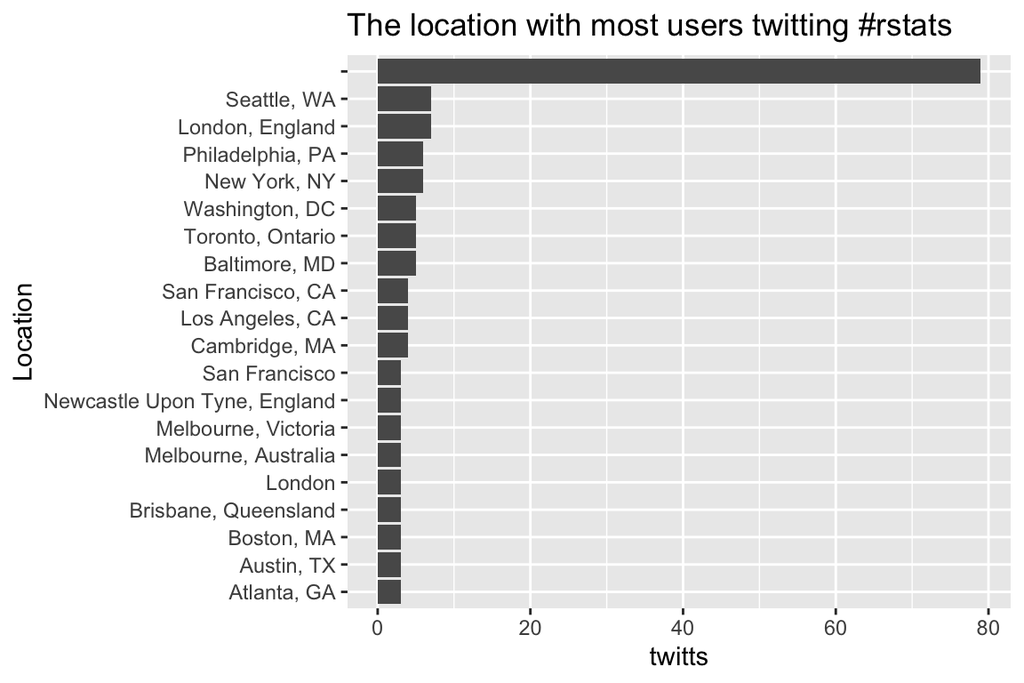

```r
rstats_users %>%
  count(location, sort = TRUE) %>%
  mutate(location = reorder(location, n)) %>%
  top_n(20) %>%
  ggplot(aes(x = location, y = n)) +
  geom_col() +
  coord_flip() +
  labs(x = "Location", y = "twitts", title = "The location with most users twitting #rstats")
```

Use the `ts_plot` function from `rtweet` to plots tweets data as a time series-like data object. The interval of time can divide into “secs”, “mins”, “hours”, “days”, “weeks”, “months”, or “years”. Notice: the time zone `tz` is defaults to “UTC”.

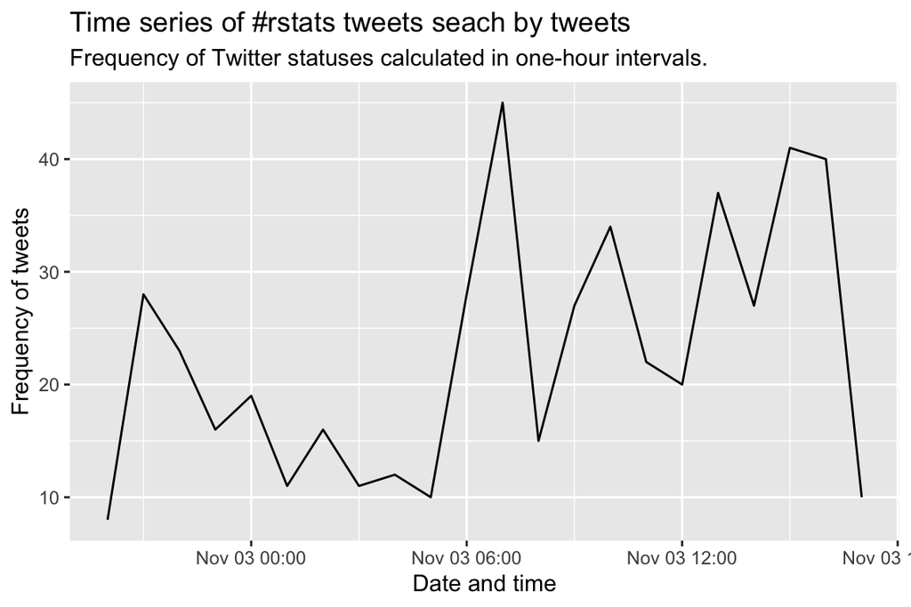

```r
rstats_tweets %>%
  ts_plot("hours", tz = ) +
  labs(x = "Date and time",
       y = "Frequency of tweets",
       title = "Time series of #rstats tweets seach by tweets",
       subtitle = "Frequency of Twitter statuses calculated in one-hour intervals.")
```

We can observed that the tweets query from the `search_users` function have capture the tweets before a few years ago.

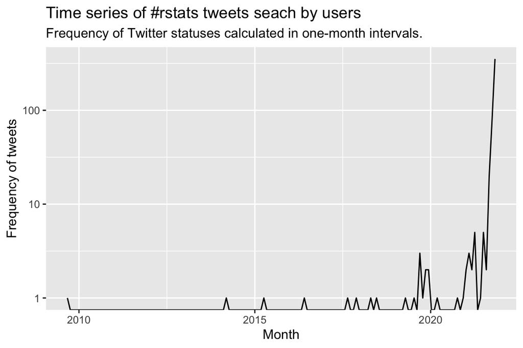

```r
rstats_users %>%
  ts_plot("months") +
  scale_y_log10() +
  labs(x = "Month",
       y = "Frequency of tweets",
       title = "Time series of #rstats tweets seach by users",
       subtitle = "Frequency of Twitter statuses calculated in one-month intervals.")
```

### Stream tweets

You can also use the `stream_tweets` to collect a live stream of Twitter data. It can returns public statuses via one of the following four methods:

1. Sampling a small random sample of all publicly available tweets

```
# Randomly sample (approximately 1%) from the live stream of all tweets
stream_tweets("")
```

2. Filtering via a search-like query (up to 400 keywords)

```
# stream tweets mentioning "election" for 30 seconds
stream_tweets("election", timeout = 30)
```

3. Tracking via vector of user ids (up to 5000 user_ids)
4. Location via geo coordinates (1-360 degree location boxes)

```
# Stream all geo-located tweets around Melbourne for 10 seconds, you need to specify the bounding box.
stream_tweets(c(-37.9, 144.7, -37.6, 145.2), timeout = 10)
# Or using the Google Maps API to lookup the coordinates
stream_tweets(lookup_coords("melbourne, aus"), timeout = 10)
```

### What the most frequent words for tweets in the past 5 seconds

```r
live_tweet <- stream_tweets(timeout = 5)
head(live_tweet$text)
```

```
## [1] "حبيت \U0001f44f\U0001f3fb❤️"
## [2] "@ppredictors BANG https://t.co/0x98qSMLMi"
## [3] "تعسر وعجل اخترت نفسي فانتهت علاقات كثيرة\nرووع ♕•ﻜٕوِدٓ•♕ قؤويي ووفعال\n$ﺧٕٓصٍٓم$\n؟؟؟\nنــّؤنْ نـوم \n \nNBF90\nNBF90\nNBF90\nwith a love that was%^^&amp;، https://t.co/kklDu47XaD"
## [4] "@craftyjan17 Evening Janice \U0001f496 You too my friend xx https://t.co/cSpAeF3NLZ"
## [5] "스트레이키즈 포카 양도 합니다 !!\n\n인증가능\n\nWTS 스키즈 스트레이키즈 한정반 특전 양도 교환 찬 방찬 bang chan 창빈 changbin 리노 현진 한 한지성 han jisung 필릭스 이용복 felix 김승민 승민 아이엔 IN StrayKids SKZ  앨범 사웨  럭드 1차 노이지 https://t.co/IcKNwFzuwN"
## [6] "#Opportunities increase when you help others #win. A win for a #partner, is a win for you. Inquire today about partnering with USFS and let’s win together. \U0001f911\nhttps://t.co/KsZ8uXdZE8 #funding #lending #loan #finance #SmallBusiness https://t.co/mqOWQptDAn"
```

```r
library(tidytext)
words <- tibble(sentence = plain_tweets(live_tweet$text)) %>%
  unnest_tokens(word, sentence)

top10 <- words%>%
  group_by(word) %>%
  tally() %>%
  top_n(10) %>%
  arrange(-n)

top10
```

```
## # A tibble: 11 × 2
##    word      n
##    <chr> <int>
##  1 t.co     82
##  2 a        35
##  3 the      34
##  4 to       30
##  5 de       23
##  6 is       18
##  7 and      17
##  8 of       17
##  9 for      15
## 10 i        15
## 11 y        15
```

### The words for tweets in the past 5 seconds

```r
library(wordcloud2)

words%>%
  group_by(word) %>%
  tally() %>%
  wordcloud2(size = 2)
```

[interactive chart not shown]